# An analysis of the collectible video game market

By Cameron Willette

## Introduction

Video games have been growing in popularity in recent years, and, as demand for them increases, so too does their prices. As a collector, I spend a lot of time tracking prices, trying to find the right time to buy and the right time to sell. In this tutorial, my aim is to walk you through the analysis of data collected on the prices of games and the creation of a model that can predict the ideal time to sell a game based on desired price and genre. Automating this process will help me learn when to prioritize certain games for my collection and reduce the amount of manual tracking I do from day to day.

I plan on following the data science pipeline to get worthwhile results. Data will be collected online and analyzed using Python code. You can see more details on the exact resources I used below.

## Resources

Throughout the project, various packages were used. To get a better understanding of their functionality, you can read their official documentation, linked here:

pandas, used for data management: https://pandas.pydata.org/pandas-docs/stable/

datetime, used to represent dates and times and easily calculate their differences: https://docs.python.org/3/library/datetime.html

matplotlib.pyplot, used for data visualization: https://matplotlib.org/3.5.0/api/_as_gen/matplotlib.pyplot.html

numpy, used for collection manipulation: https://numpy.org/doc/

scipy.stats, used for statistical analysis: https://docs.scipy.org/doc/scipy/reference/stats.html

sklearn.linear_model, used for creating models: https://scikit-learn.org/stable/modules/classes.html#module-sklearn.linear_model

sklearn.model_selection, used for testing and selecting models: https://scikit-learn.org/stable/modules/classes.html#module-sklearn.model_selection

## Data Collection

Before we can analyze data, we have to collect it. To begin this step of the process, I utilized pricecharting.com, a trusted data aggregate site in the collecting scene that tracks the average sale price of video games, trading cards and comic books across multiple storefronts. From this site, I downloaded a CSV at https://www.pricecharting.com/download-price-guide/c650d0044789fbba6e5ca58946c82f1a12a5d0e2 which contained a database of nearly 75,000 entries with the console name, the product name, the price of the game if loose, or with no box present, the price of the game with its box with all inserts, i.e. advertisements and manuals, the price with the game factory sealed, the genre and the release date. The data used in this notebook is representative of the price data as of May 10th, 2022.

After May 10th, the data used expired. So, for the sake of reproducibility, the exact data used has been uploaded at https://github.com/cam-wit/game-sale-data-may10-2022

```python
# Import the necessary package and store the CSV as a Pandas dataframe
import pandas as pd
data = pd.read_csv('price-guide.csv')
data
```

|  | id | console-name | product-name | loose-price | cib-price | new-price | genre | release-date |
| --- | --- | --- | --- | --- | --- | --- | --- | --- |
| 0 | 16491 | 3DO | 20th Century Video Almanac | $25.00 | $36.00 | $74.33 | Educational | 1993-01-01 |
| 1 | 16492 | 3DO | 3D Atlas | $26.78 | $32.45 | $64.90 | Educational | 1994-01-01 |
| 2 | 3269138 | 3DO | 3DO Action Pak | $68.55 | $152.50 | $305.00 | Action & Adventure | 1995-10-01 |
| 3 | 16493 | 3DO | 3DO Buffet | $9.99 | $13.79 | $25.45 | Other | 1995-04-27 |
| 4 | 2290650 | 3DO | 3DO CH Flight Stick Pro | NaN | NaN | NaN | Controllers | 1994-06-01 |
| ... | ... | ... | ... | ... | ... | ... | ... | ... |
| 74662 | 2587918 | ZX Spectrum | Zub | NaN | $4.70 | NaN | Action & Adventure | 1986-01-01 |
| 74663 | 2588023 | ZX Spectrum | Zulu Wars | NaN | NaN | NaN | Action & Adventure | 1987-01-01 |
| 74664 | 2588785 | ZX Spectrum | Zybex | NaN | NaN | NaN | Action & Adventure | 1989-01-01 |
| 74665 | 2588072 | ZX Spectrum | Zynaps | NaN | $11.08 | NaN | Action & Adventure | 1987-01-01 |
| 74666 | 2587700 | ZX Spectrum | Zzoom | NaN | $2.99 | $3.99 | Action & Adventure | 1983-01-01 |

74667 rows × 8 columns

## Data management/representation

Before we can start to properly visualize and analyze our data, there's some cleaning to do. We'll have to handle missing data and consider the addition of more columns.

The first step I'll be taking to clean up this data is to filter it by console name. The provided CSV includes some non-video game consoles, such as Amiibo and Disney Infinity, which are game-adjacent toy lines. It also includes listings for the same console from different regions, i.e. JP, short for Japan, and PAL, short for Phase Alternate Line, a video format standard primarily used throughout Europe. As I am primarily interested in analyzing the American game collecting scene, I don't need the data for non-video games or different regions in my dataset to perform the relevant analysis.

```python
# Print every different console present.
data['console-name'].unique()
```

```
array(['3DO', 'Action Max', 'Amiga', 'Amiga CD32', 'Amiibo',
       'Amiibo Cards', 'Arcadia 2001', 'Atari 2600', 'Atari 400',
       'Atari 5200', 'Atari 7800', 'Atari Lynx', 'Atari ST',
       'Bally Astrocade', 'CD-i', 'Colecovision', 'Commodore 64',
       'Disney Infinity', 'Evercade', 'Fairchild Channel F', 'Famicom',
       'Famicom Disk System', 'Game & Watch', 'Game.Com', 'GameBoy',
       'GameBoy Advance', 'GameBoy Color', 'Gamecube', 'Gizmondo',
       'Intellivision', 'JP GameBoy', 'JP GameBoy Advance',
       'JP GameBoy Color', 'JP Gamecube', 'JP MSX', 'JP MSX2',
       'JP Neo Geo', 'JP Neo Geo AES', 'JP Neo Geo CD',
       'JP Neo Geo Pocket Color', 'JP Nintendo 3DS', 'JP Nintendo 64',
       'JP Nintendo DS', 'JP Nintendo Switch', 'JP PC Engine',
       'JP PC Engine CD', 'JP PSP', 'JP Playstation', 'JP Playstation 2',
       'JP Playstation 3', 'JP Playstation 4', 'JP Playstation 5',
       'JP Playstation Vita', 'JP Sega Dreamcast', 'JP Sega Game Gear',
       'JP Sega Mark III', 'JP Sega Mega CD', 'JP Sega Mega Drive',
       'JP Sega Pico', 'JP Sega Saturn', 'JP Super 32X', 'JP Virtual Boy',
       'JP Wii', 'JP Wii U', 'JP Xbox', 'JP Xbox 360', 'JP Xbox One',
       'Jaguar', 'Lego Dimensions', 'Magnavox Odyssey',
       'Magnavox Odyssey 2', 'Magnavox Odyssey 300', 'Mattel Aquarius',
       'Microvision', 'Mini Arcade', 'N-Gage', 'NES', 'Neo Geo',
       'Neo Geo AES', 'Neo Geo CD', 'Neo Geo Pocket Color',
       'Nintendo 3DS', 'Nintendo 64', 'Nintendo DS', 'Nintendo Power',
       'Nintendo Switch', 'PAL Amiga CD32', 'PAL GameBoy',
       'PAL GameBoy Advance', 'PAL GameBoy Color', 'PAL Gamecube',
       'PAL MSX', 'PAL MSX2', 'PAL Mega Drive 32X', 'PAL NES',
       'PAL Neo Geo Pocket Color', 'PAL Nintendo 3DS', 'PAL Nintendo 64',
       'PAL Nintendo DS', 'PAL Nintendo Switch', 'PAL PSP',
       'PAL Playstation', 'PAL Playstation 2', 'PAL Playstation 3',
       'PAL Playstation 4', 'PAL Playstation 5', 'PAL Playstation Vita',
       'PAL Sega Dreamcast', 'PAL Sega Game Gear',
       'PAL Sega Master System', 'PAL Sega Mega CD',
       'PAL Sega Mega Drive', 'PAL Sega Saturn', 'PAL Super Nintendo',
       'PAL Vectrex', 'PAL Videopac G7000', 'PAL Videopac G7400',
       'PAL Wii', 'PAL Wii U', 'PAL Xbox', 'PAL Xbox 360', 'PAL Xbox One',
       'PAL Xbox Series X', 'PC FX', 'PSP', 'Playstation',
       'Playstation 2', 'Playstation 3', 'Playstation 4', 'Playstation 5',
       'Playstation Vita', 'Pokemon Mini', 'Rumble U', 'Sega 32X',
       'Sega CD', 'Sega Dreamcast', 'Sega Game Gear', 'Sega Genesis',
       'Sega Master System', 'Sega Pico', 'Sega Saturn', 'Skylanders',
       'Starlink', 'Strategy Guide', 'Super Famicom', 'Super Nintendo',
       'TI-99', 'Tapwave Zodiac', 'Tiger R-Zone', 'TurboGrafx CD',
       'TurboGrafx-16', 'Vectrex', 'Vic-20', 'Virtual Boy', 'Wii',
       'Wii U', 'WonderSwan', 'WonderSwan Color', 'Xbox', 'Xbox 360',
       'Xbox One', 'Xbox Series X', 'ZX Spectrum'], dtype=object)
```

```python
# Manually create an array with the relevant console listings
rel_array = ['3DO', 'Action Max', 'Amiga',
       'Arcadia 2001', 'Atari 2600', 'Atari 400',
       'Atari 5200', 'Atari 7800', 'Atari Lynx', 'Atari ST',
       'Bally Astrocade', 'CD-i', 'Colecovision', 'Commodore 64',
       'Evercade', 'Fairchild Channel F', 'Famicom',
       'Famicom Disk System', 'Game.Com', 'GameBoy',
       'GameBoy Advance', 'GameBoy Color', 'Gamecube', 'Gizmondo',
       'Intellivision', 'Jaguar', 'Magnavox Odyssey',
       'Magnavox Odyssey 2', 'Magnavox Odyssey 300', 'Mattel Aquarius',
       'Microvision', 'N-Gage', 'NES', 'Neo Geo',
       'Neo Geo AES', 'Neo Geo CD', 'Neo Geo Pocket Color',
       'Nintendo 3DS', 'Nintendo 64', 'Nintendo DS',
       'Nintendo Switch', 'PC FX', 'PSP', 'Playstation',
       'Playstation 2', 'Playstation 3', 'Playstation 4', 'Playstation 5',
       'Playstation Vita', 'Pokemon Mini', 'Sega 32X',
       'Sega CD', 'Sega Dreamcast', 'Sega Game Gear', 'Sega Genesis',
       'Sega Master System', 'Sega Pico', 'Sega Saturn',
       'Super Famicom', 'Super Nintendo',
       'TI-99', 'Tapwave Zodiac', 'Tiger R-Zone', 'TurboGrafx CD',
       'TurboGrafx-16', 'Vectrex', 'Vic-20', 'Virtual Boy', 'Wii',
       'Wii U', 'WonderSwan', 'WonderSwan Color', 'Xbox', 'Xbox 360',
       'Xbox One', 'Xbox Series X', 'ZX Spectrum']
# Filter out every row that has a console name not in our list of relevant consoles and show the data to check it
data = data[data['console-name'].isin(rel_array)]
data
```

|  | id | console-name | product-name | loose-price | cib-price | new-price | genre | release-date |
| --- | --- | --- | --- | --- | --- | --- | --- | --- |
| 0 | 16491 | 3DO | 20th Century Video Almanac | $25.00 | $36.00 | $74.33 | Educational | 1993-01-01 |
| 1 | 16492 | 3DO | 3D Atlas | $26.78 | $32.45 | $64.90 | Educational | 1994-01-01 |
| 2 | 3269138 | 3DO | 3DO Action Pak | $68.55 | $152.50 | $305.00 | Action & Adventure | 1995-10-01 |
| 3 | 16493 | 3DO | 3DO Buffet | $9.99 | $13.79 | $25.45 | Other | 1995-04-27 |
| 4 | 2290650 | 3DO | 3DO CH Flight Stick Pro | NaN | NaN | NaN | Controllers | 1994-06-01 |
| ... | ... | ... | ... | ... | ... | ... | ... | ... |
| 74662 | 2587918 | ZX Spectrum | Zub | NaN | $4.70 | NaN | Action & Adventure | 1986-01-01 |
| 74663 | 2588023 | ZX Spectrum | Zulu Wars | NaN | NaN | NaN | Action & Adventure | 1987-01-01 |
| 74664 | 2588785 | ZX Spectrum | Zybex | NaN | NaN | NaN | Action & Adventure | 1989-01-01 |
| 74665 | 2588072 | ZX Spectrum | Zynaps | NaN | $11.08 | NaN | Action & Adventure | 1987-01-01 |
| 74666 | 2587700 | ZX Spectrum | Zzoom | NaN | $2.99 | $3.99 | Action & Adventure | 1983-01-01 |

38855 rows × 8 columns

Some non-game add-ons for these consoles, such as controllers and related magazines, are still present in the data. To remedy this, I will filter by genre similarly to how I filtered by console, removing all rows with entries for genres irrelevant to my analysis.

```python
# Print every different genre present.
data['genre'].unique()
```

```
array(['Educational', 'Action & Adventure', 'Other', 'Controllers',
       'Systems', 'Demo & NFR', 'Accessories', 'Horror', 'Racing',
       'Fighting', 'Board & Card', 'Sports', 'Puzzle', "Shoot'em Up",
       'Simulation', 'Light Gun', 'FPS', 'RPG', 'Baseball', 'Golf',
       'Soccer', 'Trivia', 'Platformer', 'Football', 'Strategy',
       'Visual Novel', 'Arcade', 'Basketball', "Beat'em Up",
       'Third Person Shooter', 'Pinball', 'Casino', 'Wrestling',
       'Extreme Sports', 'Sport', 'Mini Games', 'Music', 'Party', 'Dance',
       'Compilation', 'Action ', 'Extreme', 'Magazine'], dtype=object)
```

```python
# Manually create an array with the relevant genre listings
rel_gen = ['Educational', 'Action & Adventure', 'Other',
       'Horror', 'Racing',
       'Fighting', 'Board & Card', 'Sports', 'Puzzle', "Shoot'em Up",
       'Simulation', 'Light Gun', 'FPS', 'RPG', 'Baseball', 'Golf',
       'Soccer', 'Trivia', 'Platformer', 'Football', 'Strategy',
       'Visual Novel', 'Arcade', 'Basketball', "Beat'em Up",
       'Third Person Shooter', 'Pinball', 'Casino', 'Wrestling',
       'Extreme Sports', 'Sport', 'Mini Games', 'Music', 'Party', 'Dance',
       'Action ', 'Extreme']
# Filter out every row that has a genre name not in our list of relevant genres and show the data to check it
data = data[data['genre'].isin(rel_gen)]
data
```

|  | id | console-name | product-name | loose-price | cib-price | new-price | genre | release-date |
| --- | --- | --- | --- | --- | --- | --- | --- | --- |
| 0 | 16491 | 3DO | 20th Century Video Almanac | $25.00 | $36.00 | $74.33 | Educational | 1993-01-01 |
| 1 | 16492 | 3DO | 3D Atlas | $26.78 | $32.45 | $64.90 | Educational | 1994-01-01 |
| 2 | 3269138 | 3DO | 3DO Action Pak | $68.55 | $152.50 | $305.00 | Action & Adventure | 1995-10-01 |
| 3 | 16493 | 3DO | 3DO Buffet | $9.99 | $13.79 | $25.45 | Other | 1995-04-27 |
| 17 | 35962 | 3DO | 3DO Maniac Pack | $57.57 | $73.50 | $101.98 | Other | 1995-01-01 |
| ... | ... | ... | ... | ... | ... | ... | ... | ... |
| 74662 | 2587918 | ZX Spectrum | Zub | NaN | $4.70 | NaN | Action & Adventure | 1986-01-01 |
| 74663 | 2588023 | ZX Spectrum | Zulu Wars | NaN | NaN | NaN | Action & Adventure | 1987-01-01 |
| 74664 | 2588785 | ZX Spectrum | Zybex | NaN | NaN | NaN | Action & Adventure | 1989-01-01 |
| 74665 | 2588072 | ZX Spectrum | Zynaps | NaN | $11.08 | NaN | Action & Adventure | 1987-01-01 |
| 74666 | 2587700 | ZX Spectrum | Zzoom | NaN | $2.99 | $3.99 | Action & Adventure | 1983-01-01 |

36229 rows × 8 columns

This leaves us with 36,229 entries for games released on some physical media in America. Now we have to effectively deal with missing data. First, I'll check which columns have any NaN values.

```python
# Print the number of rows that have a valid entry for each column
print(data[pd.notnull(data["id"])]["id"].count())
print(data[pd.notnull(data["console-name"])]["console-name"].count())
print(data[pd.notnull(data["product-name"])]["product-name"].count())
print(data[pd.notnull(data["loose-price"])]["loose-price"].count())
print(data[pd.notnull(data["cib-price"])]["cib-price"].count())
print(data[pd.notnull(data["new-price"])]["new-price"].count())
print(data[pd.notnull(data["genre"])]["genre"].count())
print(data[pd.notnull(data["release-date"])]["release-date"].count())
```

```
36229
36229
36229
32786
33537
32591
36229
33453
```

The above code shows that every row has a valid entry for id, console name, product name and genre, as the counts of rows whose entries for those columns is not NaN is equal to the count of all rows. However, price and release date are sometimes missing.

To see what to do about release date, let's look at some of the games with NaN as their release date.

```python
# Show all the data where the release date value is NaN
rd_na = data[data['release-date'].isna()]
rd_na
```

|  | id | console-name | product-name | loose-price | cib-price | new-price | genre | release-date |
| --- | --- | --- | --- | --- | --- | --- | --- | --- |
| 36 | 16514 | 3DO | Club 3DO: Station Invasion | $17.71 | $24.89 | $39.95 | Other | NaN |
| 53 | 66514 | 3DO | Doctor Hauzer | $14.56 | $32.00 | $64.00 | Horror | NaN |
| 56 | 16534 | 3DO | Dragon's Lair | $29.78 | $50.56 | $71.11 | Action & Adventure | NaN |
| 69 | 16542 | 3DO | Fatty Bear's Fun Pack | $23.26 | $57.96 | $78.97 | Action & Adventure | NaN |
| 88 | 16559 | 3DO | Iron Angel of the Apocalyspe: The Return | $17.01 | $32.00 | $64.00 | Action & Adventure | NaN |
| ... | ... | ... | ... | ... | ... | ... | ... | ... |
| 74632 | 2563008 | ZX Spectrum | Xevious | NaN | $3.10 | NaN | Shoot'em Up | NaN |
| 74635 | 2738728 | ZX Spectrum | Yabba Dabba Doo | NaN | NaN | NaN | Action & Adventure | NaN |
| 74649 | 2738568 | ZX Spectrum | ZIp Zap | NaN | $2.72 | NaN | Action & Adventure | NaN |
| 74655 | 2572302 | ZX Spectrum | Zipper Flipper | NaN | NaN | NaN | Pinball | NaN |
| 74661 | 2572327 | ZX Spectrum | Zorro | NaN | $6.24 | NaN | Action & Adventure | NaN |

2776 rows × 8 columns

```python
# Print all the consoles that have games with NaN release date entries
rd_na['console-name'].unique()
```

```
array(['3DO', 'Amiga', 'Atari 2600', 'Atari 400', 'Atari 5200',
       'Atari 7800', 'Atari ST', 'CD-i', 'Colecovision', 'Commodore 64',
       'Fairchild Channel F', 'Famicom', 'Famicom Disk System',
       'Game.Com', 'GameBoy', 'GameBoy Advance', 'GameBoy Color',
       'Gamecube', 'Intellivision', 'Jaguar', 'Magnavox Odyssey',
       'Magnavox Odyssey 2', 'Magnavox Odyssey 300', 'Mattel Aquarius',
       'N-Gage', 'NES', 'Neo Geo', 'Neo Geo AES', 'Neo Geo CD',
       'Neo Geo Pocket Color', 'Nintendo 3DS', 'Nintendo 64',
       'Nintendo DS', 'Nintendo Switch', 'PSP', 'Playstation',
       'Playstation 2', 'Playstation 3', 'Playstation 4', 'Playstation 5',
       'Playstation Vita', 'Sega 32X', 'Sega CD', 'Sega Dreamcast',
       'Sega Game Gear', 'Sega Genesis', 'Sega Master System',
       'Sega Pico', 'Sega Saturn', 'Super Famicom', 'Super Nintendo',
       'TI-99', 'Tapwave Zodiac', 'Tiger R-Zone', 'TurboGrafx CD',
       'TurboGrafx-16', 'Vectrex', 'Vic-20', 'Virtual Boy', 'Wii',
       'Wii U', 'WonderSwan', 'WonderSwan Color', 'Xbox', 'Xbox 360',
       'Xbox One', 'Xbox Series X', 'ZX Spectrum'], dtype=object)
```

Nothing in particular stands out about data where the relase date is listed as NaN. The vast majority of the consoles analyzed are represented, prices do not seem particularly high or low, and there is no apparent reason why the release date isn't listed. Additional research will also that the release dates for at least the first few entries are known. As this data seems to be missing for arbitrary reasons unrelated to the actual dataset, and it doesn't make up too significant a chunk of our overall dataset, rows where the release date is NaN will be dropped.

```python
# Drop all rows that have a release date of NaN and show the data to check it
data = data.dropna(subset=['release-date'])
data
```

|  | id | console-name | product-name | loose-price | cib-price | new-price | genre | release-date |
| --- | --- | --- | --- | --- | --- | --- | --- | --- |
| 0 | 16491 | 3DO | 20th Century Video Almanac | $25.00 | $36.00 | $74.33 | Educational | 1993-01-01 |
| 1 | 16492 | 3DO | 3D Atlas | $26.78 | $32.45 | $64.90 | Educational | 1994-01-01 |
| 2 | 3269138 | 3DO | 3DO Action Pak | $68.55 | $152.50 | $305.00 | Action & Adventure | 1995-10-01 |
| 3 | 16493 | 3DO | 3DO Buffet | $9.99 | $13.79 | $25.45 | Other | 1995-04-27 |
| 17 | 35962 | 3DO | 3DO Maniac Pack | $57.57 | $73.50 | $101.98 | Other | 1995-01-01 |
| ... | ... | ... | ... | ... | ... | ... | ... | ... |
| 74662 | 2587918 | ZX Spectrum | Zub | NaN | $4.70 | NaN | Action & Adventure | 1986-01-01 |
| 74663 | 2588023 | ZX Spectrum | Zulu Wars | NaN | NaN | NaN | Action & Adventure | 1987-01-01 |
| 74664 | 2588785 | ZX Spectrum | Zybex | NaN | NaN | NaN | Action & Adventure | 1989-01-01 |
| 74665 | 2588072 | ZX Spectrum | Zynaps | NaN | $11.08 | NaN | Action & Adventure | 1987-01-01 |
| 74666 | 2587700 | ZX Spectrum | Zzoom | NaN | $2.99 | $3.99 | Action & Adventure | 1983-01-01 |

33453 rows × 8 columns

The same cannot be done for NaN entries in the price columns. A NaN in any price column directly indicates that no sales of the current game in the specified conditions were found. This can indicate a couple of different things.

More likely than not, it indicates a lack of demand. However, it could also indicate a lack of supply. If there's a lack of demand, it would suggest that, were you to sell that game, it would sell for a little. But, in certain situations, where there's lack of supply, it could be worth a lot of money.

To deal with this, I'll be using various forms of data imputation.

But, before we can do that, I first need to convert the various price data from strings to float representations of dollars so I can use mathematical operations on price entries.

```python
# Iterate through each row in the dataframe
for index, row in data.iterrows():
    # For each price column, if data is present, convert it from a string to a float value representing dollar amount
    if not pd.isna(row['loose-price']):
        data.at[index, 'loose-price'] = float(row['loose-price'][1:])
    if not pd.isna(row['cib-price']):
        data.at[index, 'cib-price'] = float(row['cib-price'][1:])
    if not pd.isna(row['new-price']):
        data.at[index, 'new-price'] = float(row['new-price'][1:])

# Display the data to ensure the code worked as expected
data
```

|  | id | console-name | product-name | loose-price | cib-price | new-price | genre | release-date |
| --- | --- | --- | --- | --- | --- | --- | --- | --- |
| 0 | 16491 | 3DO | 20th Century Video Almanac | 25.0 | 36.0 | 74.33 | Educational | 1993-01-01 |
| 1 | 16492 | 3DO | 3D Atlas | 26.78 | 32.45 | 64.9 | Educational | 1994-01-01 |
| 2 | 3269138 | 3DO | 3DO Action Pak | 68.55 | 152.5 | 305.0 | Action & Adventure | 1995-10-01 |
| 3 | 16493 | 3DO | 3DO Buffet | 9.99 | 13.79 | 25.45 | Other | 1995-04-27 |
| 17 | 35962 | 3DO | 3DO Maniac Pack | 57.57 | 73.5 | 101.98 | Other | 1995-01-01 |
| ... | ... | ... | ... | ... | ... | ... | ... | ... |
| 74662 | 2587918 | ZX Spectrum | Zub | NaN | 4.7 | NaN | Action & Adventure | 1986-01-01 |
| 74663 | 2588023 | ZX Spectrum | Zulu Wars | NaN | NaN | NaN | Action & Adventure | 1987-01-01 |
| 74664 | 2588785 | ZX Spectrum | Zybex | NaN | NaN | NaN | Action & Adventure | 1989-01-01 |
| 74665 | 2588072 | ZX Spectrum | Zynaps | NaN | 11.08 | NaN | Action & Adventure | 1987-01-01 |
| 74666 | 2587700 | ZX Spectrum | Zzoom | NaN | 2.99 | 3.99 | Action & Adventure | 1983-01-01 |

33453 rows × 8 columns

We can now impute the missing data.

In cases where there are no known prices for the price in any condition, I will drop the row from the dataframe. We won't have enough data necessary to conclude whether supply or demand is the problem. It is essentially random whether or not the price would raise or lower the average. Therefore, dropping the rows should not have too much of an effect on the data present.

In cases where there is 1 known price and 2 unknown prices, I will include prices that have the same value proportional to their column mean as the known column value. I am making the assumption that supply and demand are consistent across game condtion. This is not perfect, but I believe in most situations it would be accurate. Under that assumption, this should add values that appropriately take both condition and supply/demand into account.

Based on the same assumption I just discussed, in cases where there are 2 known prices and 1 unknown price, I will include a price in the missing column that has a proportion with the column's mean value equivalent to the 2 known column's mean proportion to their column means. Similarlly, under that assumption, this should add values that appropriately take both condition and supply/demand into account.

```python
# Find the mean prices for loose games, complete-in-box games and new games
mean_loose = data['loose-price'].mean()
mean_cib = data['cib-price'].mean()
mean_new = data['new-price'].mean()

# Iterate through every row in the dataframe
for index, row in data.iterrows():
    # If no price data is known, drop the row.
    if pd.isna(row['loose-price']) and pd.isna(row['cib-price']) and pd.isna(row['new-price']):
        data = data.drop(index)
    # If 2 columns have their price data known, add the proportionally appropriate data to the unknown column
    elif pd.isna(row['loose-price']) and not pd.isna(row['cib-price']) and not pd.isna(row['new-price']):
        data.at[index, 'loose-price'] = mean_loose * ((row['cib-price']/mean_cib + row['new-price']/mean_new) / 2)
    elif not pd.isna(row['loose-price']) and pd.isna(row['cib-price']) and not pd.isna(row['new-price']):
        data.at[index, 'cib-price'] = mean_cib * ((row['loose-price']/mean_loose + row['new-price']/mean_new) / 2)
    elif not pd.isna(row['loose-price']) and not pd.isna(row['cib-price']) and pd.isna(row['new-price']):
        data.at[index, 'new-price'] = mean_new * ((row['cib-price']/mean_cib + row['loose-price']/mean_loose) / 2)
    # If 1 column has known price data, add the proportionally appropriate data to both unknown columns
    elif pd.isna(row['loose-price']) and pd.isna(row['cib-price']) and not pd.isna(row['new-price']):
        data.at[index, 'loose-price'] = mean_loose * (row['new-price']/mean_new)
        data.at[index, 'cib-price'] = mean_cib * (row['new-price']/mean_new)
    elif pd.isna(row['loose-price']) and not pd.isna(row['cib-price']) and pd.isna(row['new-price']):
        data.at[index, 'loose-price'] = mean_loose * (row['cib-price']/mean_cib)
        data.at[index, 'new-price'] = mean_new * (row['cib-price']/mean_cib)
    elif not pd.isna(row['loose-price']) and pd.isna(row['cib-price']) and pd.isna(row['new-price']):
        data.at[index, 'new-price'] = mean_new * (row['loose-price']/mean_loose)
        data.at[index, 'cib-price'] = mean_cib * (row['loose-price']/mean_loose)

# Display the data to ensure everything went as expected
data
```

|  | id | console-name | product-name | loose-price | cib-price | new-price | genre | release-date |
| --- | --- | --- | --- | --- | --- | --- | --- | --- |
| 0 | 16491 | 3DO | 20th Century Video Almanac | 25.0 | 36.0 | 74.33 | Educational | 1993-01-01 |
| 1 | 16492 | 3DO | 3D Atlas | 26.78 | 32.45 | 64.9 | Educational | 1994-01-01 |
| 2 | 3269138 | 3DO | 3DO Action Pak | 68.55 | 152.5 | 305.0 | Action & Adventure | 1995-10-01 |
| 3 | 16493 | 3DO | 3DO Buffet | 9.99 | 13.79 | 25.45 | Other | 1995-04-27 |
| 17 | 35962 | 3DO | 3DO Maniac Pack | 57.57 | 73.5 | 101.98 | Other | 1995-01-01 |
| ... | ... | ... | ... | ... | ... | ... | ... | ... |
| 74659 | 2589125 | ZX Spectrum | Zona 0 | 78.383079 | 139.75 | 341.019461 | Action & Adventure | 1991-01-01 |
| 74660 | 2588627 | ZX Spectrum | Zone Trooper | 7.033444 | 12.54 | 30.600244 | Action & Adventure | 1989-01-01 |
| 74662 | 2587918 | ZX Spectrum | Zub | 2.636139 | 4.7 | 11.468991 | Action & Adventure | 1986-01-01 |
| 74665 | 2588072 | ZX Spectrum | Zynaps | 6.214558 | 11.08 | 27.037536 | Action & Adventure | 1987-01-01 |
| 74666 | 2587700 | ZX Spectrum | Zzoom | 1.297066 | 2.99 | 3.99 | Action & Adventure | 1983-01-01 |

31660 rows × 8 columns

The data is almost ready for exploration now, but I'd like to add a few more columns that may be useful in further analysis. Namely, I'd like to get a release year column and an age column.

I'll first convert the release-date column entries to datetime objects instead of strings so I can easily calculate the amount of days that have passed since a game's release and easily extract the year value.

```python
# Import the necessary package
import datetime

# Iterate through each row, converting the release date string to a datetime object representative of the same date
for index, row in data.iterrows():
    data.loc[index,'release-date'] = datetime.datetime(int(row['release-date'][0:4]), int(row['release-date'][5:7]), int(row['release-date'][8:10]))

# Display the data to check that everything went as expected
data
```

|  | id | console-name | product-name | loose-price | cib-price | new-price | genre | release-date |
| --- | --- | --- | --- | --- | --- | --- | --- | --- |
| 0 | 16491 | 3DO | 20th Century Video Almanac | 25.0 | 36.0 | 74.33 | Educational | 1993-01-01 00:00:00 |
| 1 | 16492 | 3DO | 3D Atlas | 26.78 | 32.45 | 64.9 | Educational | 1994-01-01 00:00:00 |
| 2 | 3269138 | 3DO | 3DO Action Pak | 68.55 | 152.5 | 305.0 | Action & Adventure | 1995-10-01 00:00:00 |
| 3 | 16493 | 3DO | 3DO Buffet | 9.99 | 13.79 | 25.45 | Other | 1995-04-27 00:00:00 |
| 17 | 35962 | 3DO | 3DO Maniac Pack | 57.57 | 73.5 | 101.98 | Other | 1995-01-01 00:00:00 |
| ... | ... | ... | ... | ... | ... | ... | ... | ... |
| 74659 | 2589125 | ZX Spectrum | Zona 0 | 78.383079 | 139.75 | 341.019461 | Action & Adventure | 1991-01-01 00:00:00 |
| 74660 | 2588627 | ZX Spectrum | Zone Trooper | 7.033444 | 12.54 | 30.600244 | Action & Adventure | 1989-01-01 00:00:00 |
| 74662 | 2587918 | ZX Spectrum | Zub | 2.636139 | 4.7 | 11.468991 | Action & Adventure | 1986-01-01 00:00:00 |
| 74665 | 2588072 | ZX Spectrum | Zynaps | 6.214558 | 11.08 | 27.037536 | Action & Adventure | 1987-01-01 00:00:00 |
| 74666 | 2587700 | ZX Spectrum | Zzoom | 1.297066 | 2.99 | 3.99 | Action & Adventure | 1983-01-01 00:00:00 |

31660 rows × 8 columns

Now I can add the release year and age columns. Age will be represented in days between release and May 10th, 2022, the day the data was collected.

```python
# Create a datetime object representative of the date the dataset used was collected
coll_day = datetime.datetime(2022, 5, 10)

# Iterate through each row, adding a value for release year and age in days
for index, row in data.iterrows():
    data.loc[index,'release-year'] = row['release-date'].year
    data.loc[index,'age'] = (coll_day - row['release-date']).days

# Display the data to ensure everything went as expected
data
```

|  | id | console-name | product-name | loose-price | cib-price | new-price | genre | release-date | release-year | age |
| --- | --- | --- | --- | --- | --- | --- | --- | --- | --- | --- |
| 0 | 16491 | 3DO | 20th Century Video Almanac | 25.0 | 36.0 | 74.33 | Educational | 1993-01-01 00:00:00 | 1993.0 | 10721.0 |
| 1 | 16492 | 3DO | 3D Atlas | 26.78 | 32.45 | 64.9 | Educational | 1994-01-01 00:00:00 | 1994.0 | 10356.0 |
| 2 | 3269138 | 3DO | 3DO Action Pak | 68.55 | 152.5 | 305.0 | Action & Adventure | 1995-10-01 00:00:00 | 1995.0 | 9718.0 |
| 3 | 16493 | 3DO | 3DO Buffet | 9.99 | 13.79 | 25.45 | Other | 1995-04-27 00:00:00 | 1995.0 | 9875.0 |
| 17 | 35962 | 3DO | 3DO Maniac Pack | 57.57 | 73.5 | 101.98 | Other | 1995-01-01 00:00:00 | 1995.0 | 9991.0 |
| ... | ... | ... | ... | ... | ... | ... | ... | ... | ... | ... |
| 74659 | 2589125 | ZX Spectrum | Zona 0 | 78.383079 | 139.75 | 341.019461 | Action & Adventure | 1991-01-01 00:00:00 | 1991.0 | 11452.0 |
| 74660 | 2588627 | ZX Spectrum | Zone Trooper | 7.033444 | 12.54 | 30.600244 | Action & Adventure | 1989-01-01 00:00:00 | 1989.0 | 12182.0 |
| 74662 | 2587918 | ZX Spectrum | Zub | 2.636139 | 4.7 | 11.468991 | Action & Adventure | 1986-01-01 00:00:00 | 1986.0 | 13278.0 |
| 74665 | 2588072 | ZX Spectrum | Zynaps | 6.214558 | 11.08 | 27.037536 | Action & Adventure | 1987-01-01 00:00:00 | 1987.0 | 12913.0 |
| 74666 | 2587700 | ZX Spectrum | Zzoom | 1.297066 | 2.99 | 3.99 | Action & Adventure | 1983-01-01 00:00:00 | 1983.0 | 14374.0 |

31660 rows × 10 columns

Before we move on, I'd like to check that the release year values make sense. All video games were released after the 1960s and we can't know the price of unreleased games, so all years should be between 1960 and 2022.

```python
# Display the unique release years
data['release-year'].unique()
```

```
array([1.993e+03, 1.994e+03, 1.995e+03, 1.996e+03, 1.987e+03, 1.990e+03,
       1.992e+03, 1.986e+03, 1.991e+03, 1.989e+03, 1.983e+03, 1.982e+03,
       1.988e+03, 1.980e+03, 2.019e+03, 1.979e+03, 1.977e+03, 2.020e+03,
       1.981e+03, 2.021e+03, 1.978e+03, 1.985e+03, 1.984e+03, 2.012e+03,
       2.018e+03, 2.001e+03, 2.006e+03, 2.011e+03, 2.016e+03, 2.000e+03,
       2.007e+03, 2.002e+03, 2.013e+03, 2.014e+03, 2.004e+03, 1.999e+03,
       1.997e+03, 2.010e+03, 2.003e+03, 1.998e+03, 2.017e+03, 2.009e+03,
       2.022e+03, 1.976e+03, 1.905e+03, 2.005e+03, 2.008e+03, 2.015e+03,
       1.972e+03, 1.000e+00, 1.100e+01])
```

Most of the data looks valid, but there are games that were apparently released in the year 1905, the year 1, and the year 11. Let's see what those data points are.

```python
# Locate the relevant rows and print them
print(data.loc[data['release-year'] == 1905.0])
print(data.loc[data['release-year'] == 1.0])
print(data.loc[data['release-year'] == 11.0])
```

```
         id console-name                            product-name loose-price  \
4577  42836      Famicom                 Keiba Simulation Honmei        1.38
4678  42976      Famicom  Meitantei Holmes: M Kara no Chousenjou        2.05

     cib-price new-price               genre         release-date  \
4577      4.45      14.0  Action & Adventure  1905-06-11 00:00:00
4678      8.86      28.0  Action & Adventure  1905-06-11 00:00:00

      release-year      age
4577        1905.0  42702.0
4678        1905.0  42702.0
          id   console-name                              product-name  \
52216  62537  Playstation 3  Assassin's Creed III [Steelbook Edition]

      loose-price cib-price new-price               genre  \
52216         9.8     11.82      20.5  Action & Adventure

              release-date  release-year       age
52216  0001-03-10 00:00:00           1.0  738216.0
          id console-name                                      product-name  \
69708  65435     Xbox 360  Halo: Combat Evolved Anniversary [Platinum Hits]

      loose-price cib-price new-price genre         release-date  \
69708       12.72     14.69     45.22   FPS  0011-11-15 00:00:00

       release-year       age
69708          11.0  734314.0
```

It seems like this was a simple data entry error, all four of these games have known release dates. Since only 4 rows were affected, I'll manually correct the date-focused info based on the release date listed on Wikipedia.

```python
# Manually correct the date-centric data for Keiba Simulation Honmei
data.at[4577,'release-date'] = datetime.datetime(1989, 4, 28)
data.at[4577,'release-year'] = 1989
data.at[4577,'age'] = (coll_day - datetime.datetime(1989, 4, 28)).days

# Manually correct the date-centric data for Meitantei Holmes: M Kara no Chousenjou
data.at[4678,'release-date'] = datetime.datetime(1989, 5, 1)
data.at[4678,'release-year'] = 1989
data.at[4678,'age'] = (coll_day - datetime.datetime(1989, 5, 1)).days

# Manually correct the date-centric data for Assassin's Creed III [Steelbook Edition]
data.at[52216,'release-date'] = datetime.datetime(2012, 10, 30)
data.at[52216,'release-year'] = 2012
data.at[52216,'age'] = (coll_day - datetime.datetime(2012, 10, 30)).days

# Manually correct the date-centric data for Halo: Combat Evolved Anniversary [Platinum Hits]
data.at[69708,'release-date'] = datetime.datetime(2011, 11, 15)
data.at[69708,'release-year'] = 2011
data.at[69708,'age'] = (coll_day - datetime.datetime(2011, 11, 15)).days
```

Now we should be good to go into the exploratory data analysis phase.

## Exploratory data analysis

This phase of the data science pipeline is vital to the formation of hypotheses that can be analyzed. I'll be creating various visualizations of data that I can use as a basis for the hypotheses I will be testing in the next phase.

To first see if I can detect any general trends, I'll be creating bar charts for the average price of games by condition, by genre and by year.

Let's start by making a bar graph to see if condition has an affect on game price

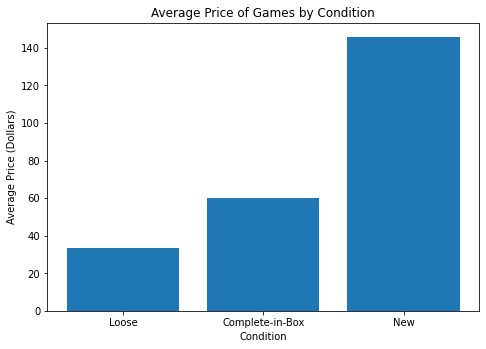

```python
# Import the necessary package
import matplotlib.pyplot as plt

# Get a list of labels for condition and compile the average prices per condition collected before into a list
conditions = ['Loose', 'Complete-in-Box', 'New']
avg_prices = [mean_loose, mean_cib, mean_new]

# Plot the data and label the graph
fig = plt.figure()
ax = fig.add_axes([0,0,1,1])
ax.bar(conditions,avg_prices)
plt.xlabel("Condition")
plt.ylabel("Average Price (Dollars)")
plt.title("Average Price of Games by Condition")
plt.show()
```

Unsurprisingly, it seems that condition does have an effect on average price. In general, loose games are worth less than complete-in-box games, which are worth less than new games.

Now let's make some bar graphs that plot average price against genre for each game condition.

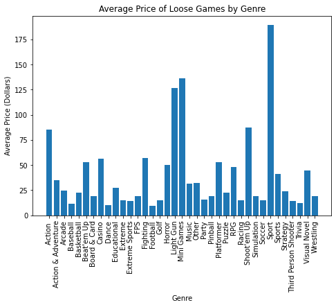

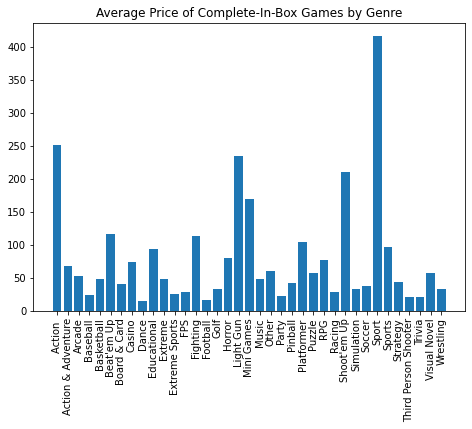

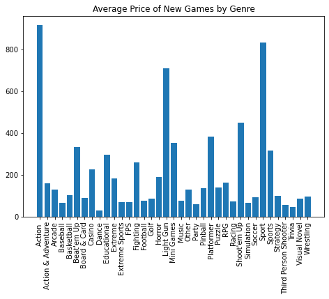

```python
# Group the data by genre. Then create lists with the average price of each condition per genre.
gb = data.groupby('genre')
avg_price_loose = [gb.get_group(x)['loose-price'].mean() for x in gb.groups]
avg_price_cib = [gb.get_group(x)['cib-price'].mean() for x in gb.groups]
avg_price_new = [gb.get_group(x)['new-price'].mean() for x in gb.groups]

# Create a figure, label it correctly and plot the dataset
fig = plt.figure()
ax = fig.add_axes([0,0,1,1])
plt.xticks(rotation=90)
ax.bar(gb.groups.keys(),avg_price_loose)
plt.xlabel("Genre")
plt.ylabel("Average Price (Dollars)")
plt.title("Average Price of Loose Games by Genre")
plt.show()

# Repeat the above step for the other 2 datasets
fig = plt.figure()
ax = fig.add_axes([0,0,1,1])
plt.xticks(rotation=90)
ax.bar(gb.groups.keys(),avg_price_cib)
plt.title("Average Price of Complete-In-Box Games by Genre")
plt.show()

fig = plt.figure()
ax = fig.add_axes([0,0,1,1])
plt.xticks(rotation=90)
ax.bar(gb.groups.keys(),avg_price_new)
plt.title("Average Price of New Games by Genre")
plt.show()
```

There are a couple of key observations we can make from these graphs.

Firstly, it appears that genre does have a significant effect on price. There's a huge range in the price by genre values across all conditions.

Second, it seems that the genres that pull in the most money and the least money are fairly consistent across game condition. There are some exceptions, for example platformers seem, in relative terms, particularly valuable new, and mini games seem particularly valuable loose. However, genres such as action, light gun, shoot 'em up and sport titles are all particularly valuable across all conditions relative to other genres, and genres such as dance, trivia and party are particularly unvaluable across all conditions relative to other genres.

Since value is relatively consistent across game conditions, I will now make a single bar graph for analysis plotting average game price across all conditions per genre. It seems that genre's effect on value is fairly consistent across conditions, so this single graph should be accurate, it should display the same trends and it will be easier to use for further analysis.

[figure not shown]

```python
# Get a list with the average price across all conditions by genre
avg_price_all = [((gb.get_group(x)['loose-price'].mean() + gb.get_group(x)['cib-price'].mean() + gb.get_group(x)['new-price'].mean())/3) for x in gb.groups]

# Create a figure, label it correctly and plot the dataset
fig = plt.figure()
ax = fig.add_axes([0,0,1,1])
plt.xticks(rotation=90)
ax.bar(gb.groups.keys(),avg_price_all)
plt.xlabel("Genre")
plt.ylabel("Average Price (Dollars)")
plt.title("Average Price of Loose Games by Genre")
plt.show()
```

As expected, action, light gun, shoot 'em up and sport games still lie near the top, while dance, party and trivia games still lie near the bottom. This bar graph looks very similar in shape to the ones created for each individual game condition.

I'll now make a bar graph of release year vs. average price across game conditions.

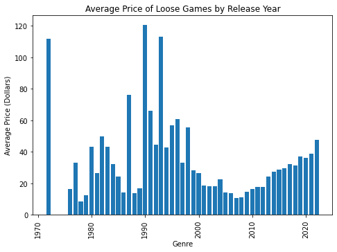

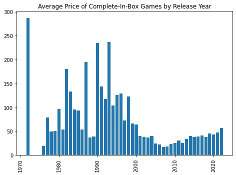

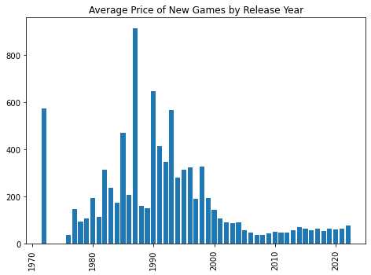

```python
# Group data by release year and get average prices
gb = data.groupby('release-year')
avg_price_loose = [gb.get_group(x)['loose-price'].mean() for x in gb.groups]
avg_price_cib = [gb.get_group(x)['cib-price'].mean() for x in gb.groups]
avg_price_new = [gb.get_group(x)['new-price'].mean() for x in gb.groups]

# Create a figure, label it correctly and plot the dataset
fig = plt.figure()
ax = fig.add_axes([0,0,1,1])
plt.xticks(rotation=90)
ax.bar(gb.groups.keys(),avg_price_loose)
plt.xlabel("Genre")
plt.ylabel("Average Price (Dollars)")
plt.title("Average Price of Loose Games by Release Year")
plt.show()

# Repeat the above step for the other 2 datasets
fig = plt.figure()
ax = fig.add_axes([0,0,1,1])
plt.xticks(rotation=90)
ax.bar(gb.groups.keys(),avg_price_cib)
plt.title("Average Price of Complete-In-Box Games by Release Year")
plt.show()

fig = plt.figure()
ax = fig.add_axes([0,0,1,1])
plt.xticks(rotation=90)
ax.bar(gb.groups.keys(),avg_price_new)
plt.title("Average Price of New Games by Release Year")
plt.show()
```

In general, all three graphs follow a similar trend. The very first games released, which hold significant historical value, and the games released in the late 1980s, which are the origin of many long-running franchises, seem to be particularly valuable.

It is worth noting how very recently released loose games show a slight spike in value. However, if you look at the actual prices, you can see that the average price of loose games released in the 2020s are still below the standard 60 or 70 dollar MSRP for new games.

Another thing I'd like to look at is to see the breakdown of price by platform, to see if there's any relation there.

[figure not shown]

[figure not shown]

[figure not shown]

```python
# Group data by console and get average prices
gb = data.groupby('console-name')
avg_price_loose = [gb.get_group(x)['loose-price'].mean() for x in gb.groups]
avg_price_cib = [gb.get_group(x)['cib-price'].mean() for x in gb.groups]
avg_price_new = [gb.get_group(x)['new-price'].mean() for x in gb.groups]

# Increase the figure size so each x-tick label is clearly visible
plt.rcParams["figure.figsize"] = (10,6)

# Create a figure, label it correctly and plot the dataset
fig = plt.figure()
ax = fig.add_axes([0,0,1,1])
plt.xticks(rotation=90)
ax.bar(gb.groups.keys(),avg_price_loose)
plt.xlabel("Genre")
plt.ylabel("Average Price (Dollars)")
plt.title("Average Price of Loose Games by Genre")
plt.show()

# Repeat the above step for the other 2 datasets
fig = plt.figure()
ax = fig.add_axes([0,0,1,1])
plt.xticks(rotation=90)
ax.bar(gb.groups.keys(),avg_price_cib)
plt.title("Average Price of Complete-In-Box Games by Genre")
plt.show()

fig = plt.figure()
ax = fig.add_axes([0,0,1,1])
plt.xticks(rotation=90)
ax.bar(gb.groups.keys(),avg_price_new)
plt.title("Average Price of New Games by Genre")
plt.show()
```

As expected, these graphs look very similar in shape, having platforms with the same peaks and dips across all game conditions.

I am surprised to see some notable failures that were followed up with major successes, such as the Wii U, which released before the Nintendo Switch, not have notable peaks. I will be curious to see if it experiences a peak in game price in the future like we see with older Nintendo failures, such as the Virtual Boy.

Old Nintendo consoles seem to have particularly high-value games, even if the consoles and games were big successes. New NES games are particularly valuable, and I predict that this is because there is a limited supply of new NES games. People weren't purchasing Nintendo games expecting them to be collectible in the future when they first released. I don't think a spike of that magnitude will be seen for modern Nintendo platforms in the future as a result now that the collecting scene is more established.

The Neo Geo prices are particularly high. Neo Geo games were already relatively high in cost when they released, and the company that made the Neo Geo, SNK, still produces new titles, such as this year's King of Fighters XV. The console was also not particularly successful. New fans are being made and supply is low so the high value across all conditions makes sense.

I'd now like to create a couple violin plots to see the differing distributions of price by platform and genre. Let's start with platform, using complete-in-box price exclusively. We now know that the general trends are similar between each condition, so this distribution will likely be representative of the distribution of prices for other conditions as well.

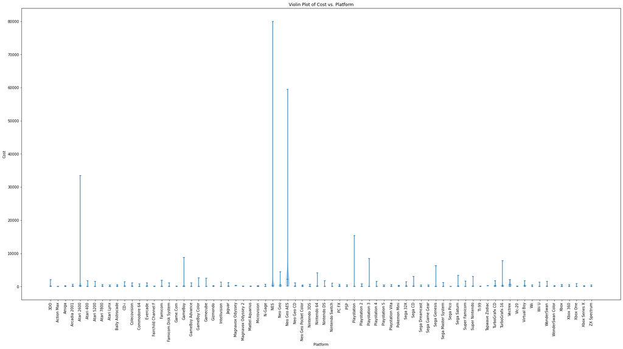

```python
# Alter the plot size so the data is clearly visible
plt.rcParams["figure.figsize"] = (30, 15)

# Collect lists of platform and genre to use for plotting
platforms = data['console-name'].unique()
genres = data['genre'].unique()

# Get a list of lists of prices by platform
cib_platform = [gb.get_group(x)['cib-price'].values.astype('float64').tolist() for x in gb.groups]

# Populate a position list to properly space out the differing distriubtions
pos = []
for x in range(0,len(platforms)):
    pos.append(8 * x)


# Create and label the violin plot
fig, ax = plt.subplots()
plt.xticks(rotation=90)
ax.violinplot(cib_platform, pos, widths=4,showmeans=True)
ax.set_xticks(pos)
ax.set_xticklabels(platforms)
ax.set_xlabel("Platform")
ax.set_ylabel("Cost")
ax.set_title("Violin Plot of Cost vs. Platform")
```

This graph is pretty interesting. Due to the huge values of some outliers, it's hard to properly visualize the actual distributions. As a result, I won't make any conclusions about the distributions based on this graph. Instead, I'd like to further analyze the outliers. I do think it's interesting how the consoles with the highest peak prices are not necessarily the consoles with the highest average prices. This graph shows us that the most expensive TurboGrafx-16 title is far more expensive than the priciest Vectrex title, for example, though the earlier graphs show us that the average Vectrex game is a lot more expensive than the average TurboGrafx-16 title.

Let's see if the genre violin plot looks similar.

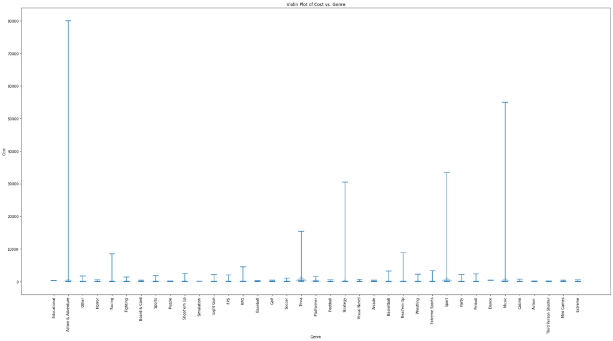

```python
# Group the data by genre
gb = data.groupby('genre')

# Get a list of lists of prices per genre
cib_genre = [gb.get_group(x)['cib-price'].values.astype('float64').tolist() for x in gb.groups]

# Get a list of positions for the proper spacing of the distributions
pos = []
for x in range(0,len(genres)):
    pos.append(5 * x)


# Create and label the violin plot
fig, ax = plt.subplots()
plt.xticks(rotation=90)
ax.violinplot(cib_genre, pos, widths=4,showmeans=True)
ax.set_xticks(pos)
ax.set_xticklabels(genres)
ax.set_xlabel("Genre")
ax.set_ylabel("Cost")
ax.set_title("Violin Plot of Cost vs. Genre")
```

Looks like, once again, the outliers are so large that the actual distributions are very hard to see. It is interesting to me that, as with platforms, genres with the highest max and average prices are considerably different. The average Action & Adventure title is not particularly expensive, though the priciest one is by far the most valuable game in the dataset.

Let's take a look at the 5 most valuable games and see if there's a pattern there, seeing as how these outliers seem so far from the averages.

```python
dataSort = data.sort_values('cib-price')
print(dataSort.iloc[len(dataSort)-1])
print(dataSort.iloc[len(dataSort)-2])
print(dataSort.iloc[len(dataSort)-3])
print(dataSort.iloc[len(dataSort)-4])
print(dataSort.iloc[len(dataSort)-5])
```

```
id                                    14933
console-name                            NES
product-name    Nintendo World Championship
loose-price                        44853.75
cib-price                      79970.213974
new-price                     195144.180691
genre                    Action & Adventure
release-date            1990-12-01 00:00:00
release-year                         1990.0
age                                 11483.0
Name: 18871, dtype: object
id                            37807
console-name            Neo Geo AES
product-name             Metal Slug
loose-price                26444.44
cib-price                   59500.0
new-price                  119000.0
genre            Action & Adventure
release-date    1993-01-01 00:00:00
release-year                 1993.0
age                         10721.0
Name: 19521, dtype: object
id                                          12224
console-name                                  NES
product-name    Family Fun Fitness Stadium Events
loose-price                               19411.5
cib-price                                 55000.0
new-price                                247822.0
genre                                      Sports
release-date                  1987-09-01 00:00:00
release-year                               1987.0
age                                       12670.0
Name: 18507, dtype: object
id                            37892
console-name            Neo Geo AES
product-name       Neo Turf Masters
loose-price                16738.93
cib-price                  34937.87
new-price                   69876.0
genre                        Sports
release-date    1996-03-06 00:00:00
release-year                 1996.0
age                          9561.0
Name: 19532, dtype: object
id                                         16173
console-name                                 NES
product-name    Nintendo World Championship Gold
loose-price                             18944.25
cib-price                           33775.898918
new-price                           82420.313687
genre                         Action & Adventure
release-date                 1990-12-01 00:00:00
release-year                              1990.0
age                                      11483.0
Name: 18872, dtype: object
```

Interestingly enough, the titles only span 2 consoles and 2 genres. The 3 NES titles, Nintendo World Championship, Nintendo World Championship Gold and Family Fun Fitness Stadium Events were never given a wide release, they were all used as promotional materials for contests. This explains why they're so valuable. The Neo-Geo AES titles, however, were given worldwide releases. This further suggests that Neo-Geo titles may be particularly valuable.

Now that we have some data, we can move on to testing some hypotheses

## Hypothesis testing

Hypothesis testing is the phase of the data science pipeline where we get tangible data that allows us to make conclusions. I will be testing a couple hypotheses I developed in my prior exploration of the data.

I suspect that the less prevelant a genre, or the less listings of it there are, the more valuable a game in it will be. A limited variety of games in a genre could indicate a lack of demand, as, with demand present, developers would likely produce more similar games. But it also indicates a lack of supply. Fans of that genre have limited options and may be willing to shell out high amounts of cash to get the games they want.

I will plot average price per genre against count of games per genre to further investigate.

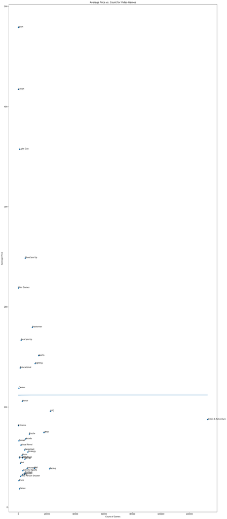

```python
# Import the necessary package
import numpy as np

# Get a list of the counts of each game per genre
gb = data.groupby('genre')
counts = [gb.get_group(x).size for x in gb.groups]

# Increase the figure sizze so every datapoint label is clearly visible despite the high concentration in the bottom left
plt.rcParams["figure.figsize"] = (20, 50)

# Label the graph and scatter the points
plt.figure()
plt.xlabel("Count of Games")
plt.ylabel("Average Price")
plt.title("Average Price vs. Count for Video Games")
plt.scatter(counts, avg_price_all)
# Label each scattered point
for i,label in enumerate(gb.groups.keys()):
    plt.text(counts[i], avg_price_all[i],label)
# Calculate m and b for the regression line and plot that line
m, b = np.polyfit(np.array(counts), np.array(avg_price_all), 1)
plt.plot(counts, m * np.array(avg_price_all) + b)
```

This graph suggests that my theory is probably incorrect. The regression line does not fit the data very well, and we can observe that relatively unvaluable genres such as dance have lower counts than relatively valuable genres such as shoot 'em ups. Still, I will move forward with hypothesis testing.

The null hypothesis will be that there is no correlation between amount of games per genre and value.

The alternative hypothesis will be that there is a correlation.

A Pearson's correlation test will be performed to get the p-value and see if we can reject the null hypothesis.

```python
# Import the necessary package
from scipy.stats import pearsonr

# Calculate the p-value for testing if there is a correlation between counts and price, and display it
stat, p = pearsonr(counts, avg_price_all)
p
```

```
0.6345896162127201
```

This p-value is very high, so there is no evidence that we should reject the null hypothesis. We can therefore conclude that we do not have statistically significant evidence that there is a correlation between the amount of games in a genre and the value of games in a genre. I now know that I should not prioritize genre scarcity in building up my collection.

I'd also like to explore the hypothesis that Neo-Geo titles are not valued the same as the average game. The null hypothesis is that games for the Neo-Geo AES are worth about the same as any game, while the alternative hypothesis is that they are not.

3 Student's t-tests, one for each game condition, will be performed to get the p-value and see if we can reject the null hypothesis.

```python
# Import the necessary package
from scipy.stats import ttest_ind

# Get a dataframe that only holds data for games on the Neo Geo AES
neo_geo_data = data[data['console-name'] == 'Neo Geo AES']

# Run the t-test for loose games
stat, p = ttest_ind(neo_geo_data['loose-price'], data['loose-price'])
print(p)

# Run the t-test for complete-in-box games
stat, p = ttest_ind(neo_geo_data['cib-price'], data['cib-price'])
print(p)

# Run the t-test for new games
stat, p = ttest_ind(neo_geo_data['new-price'], data['new-price'])
print(p)
```

```
5.883105767623169e-150
1.7902653252334758e-131
2.3297966331472652e-73
```

All 3 p-values are exceptionally small, meaning we can reject the null hypothesis for each condition. That means that we have statistically significant evidence that Neo Geo AES titles are valued differently than the average game. This suggests that I can not apply any standard collection rules in an attempt to build a Neo Geo AES collection. It also suggests that a model that attempts to estimate something like the ideal time to sell a game may not work across all platforms.

Still, I'll try to make the model I discussed at the beginning of this notebook.

## Machine learning

The exact goal here will be creating a model that can ideally output the age at which the game should be priced at an inputted value given genre. I will be focusing on the complete-in-box prices as that is how I personally collect games, generally opening them and playing them but keeping all the components together and in good condition.

For example, say I want to buy a Xenoblade Chronicles 3, an upcoming RPG, for $40 complete-in-box. By inputting its genre and my desired price, I hope that my model will be able to output the age at which that game will be available for that price. I will be making a linear model due to its simplicity with regards to implementation and testing, and I will be using interaction terms to account for genre's impact despite genre not having a numerical representation.

```python
# Import the necessary packages
from sklearn.linear_model import LinearRegression
from sklearn.model_selection import train_test_split

# Use get dummies to encode genre numerically, and add that encoding to the features used for prediction
genre_feature = pd.get_dummies(data['genre'], drop_first=True, prefix = "genre")
standard_features = data[['cib-price', 'genre']]
comb_feat = pd.concat([standard_features, genre_feature], axis=1)

# Get a list of genres
genres = list(set(data.genre.values))

# Get a value for the interaction between cib-price and genre
for s in filter(lambda s : s != 'Action ', genres):
    comb_feat["cib-price*" + s] = comb_feat["genre_" + s]*comb_feat["cib-price"]

# Get the x and y used for prediction
x = comb_feat.drop('genre', axis = 1)
y = np.array(data['age']).reshape(-1, 1)

# Split the data into training sets containing 80% of the data and testing sets containing 20% of the data
x_train, x_test, y_train,y_test = train_test_split(x,y,test_size =0.2)

# Fit the model on the training set and print a representation of its accuracy on the testing set, the coefficient of determination.
lm = LinearRegression()
lm.fit(x_train, y_train)
lm.score(x_test,y_test)
```

```
0.027614666789533615
```

This coefficient of determination is quite small, my model is supposedly accurate less than 5% of the time. Therefore, I should not be using it if I want accurate predictions.

## Conclusions

In conclusion, it seems that the video game market is quite hard to predict. It's easy to prove that certain consoles or genres that already exist hold games of greater value, though extrapolating that data has lead to mixed results at best.

No strong correlations were found in any of my testing, and the model I created was largley inaccurate. It seems that genre alone is not enough to determine a game's value. I suspect that, if I took platform into account as well with my model, it would be more accurate. However, that would not allow for me to apply this model in predicting the value for releases on future consoles, which is what I was hoping to be able to do.

In the future, adding to this dataset with data relevant to individual game sales and console sales would be interesting. Perhaps also adding the publisher of a game would be useful. Based on my experience collecting, I suspect some correlations would be found between console sales and value and game sales and value. I also suspect there'd be a relationship between publisher and value. With these extra features, I believe a stronger model could be generated. As it is now, we can only conclude that the current dataset wasn't enough to generate the ideal model.